# Cover

04-06-2026

How to build a real-life theory of change from your interviews using AI:

a Causal Map 4 training session

## The team

Steve Powell, Co-founder and Director, Causal Map Ltd

[figure not shown]

Gabriele Caldas Cabral, Outreach Coordinator, Causal Map Ltd

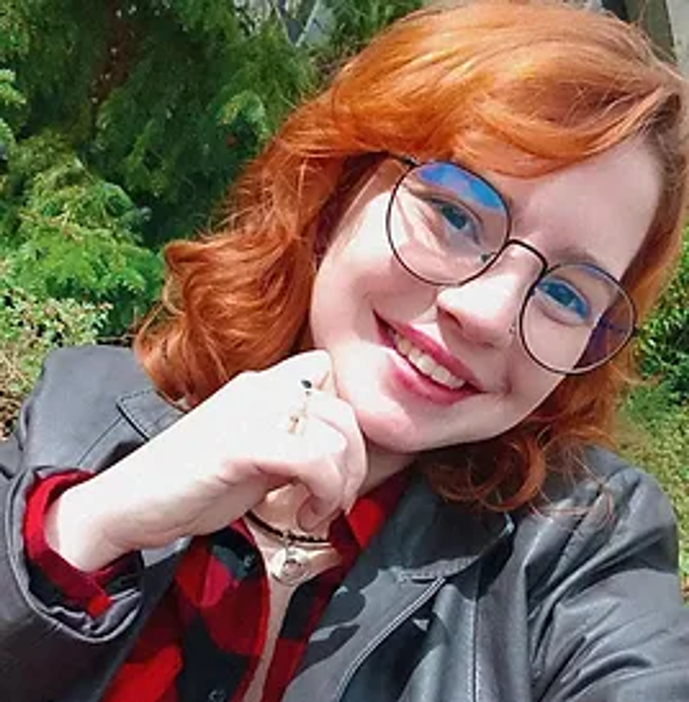

What we will do today: explain what is causal mapping and how to do it with AI, turning your text data into a theory of change, and learn to question it. About 90 minutes, with plenty of room for your questions!

# You have a stack of interviews

You have a stack of interviews

## Somewhere in there is your answer

Interviews. Reports. Open survey answers. Pages of people telling you what changed and why.

Somewhere in there is the answer to your question. How do you get it out, in a way you can stand behind?

## Two tempting shortcuts, both bad

**Hand it to the black box.** shortcut 1 “ChatGPT, what does this say?” Fast and fluent, but you cannot see what it leaned on, so you cannot defend the answer.

**Read it all yourself.** shortcut 2 Thorough, but it does not scale. Three hundred transcripts, and you still have to show your synthesis really reflects what people said.

There is a better way.

## The plan for today

One route from your interviews to a theory of change you can defend:

- start from interviews, reports, open answers, any narrative data
- turn what people said into a map of causes and effects, with AI
- question that map until you have an answer

AI does the patient clerical work. You make the judgements.

# Why causal mapping

Why causal mapping

## What we do when we do causal mapping

Researchers have been doing causal mapping for 50 years.

You read the text and mark each causal claim as a link from one factor to another.

> “The training gave me confidence, and that is why I started the business.”

This becomes training → confidence → started a business, keeping the exact quote and the source on every link.

Do that across all your interviews and the links join up into a map: your theory of change, built from what people actually said.

## coding

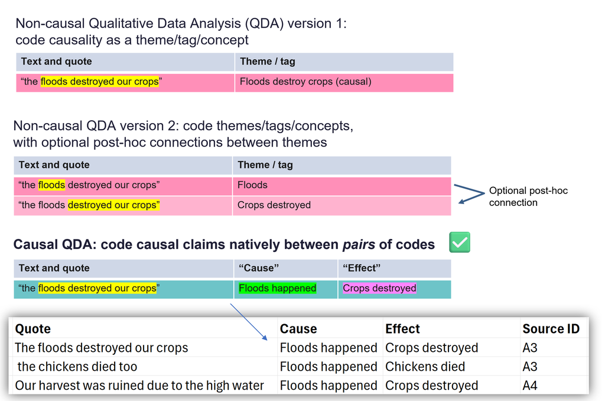

## We code claims, not facts

A link means: this person says X influenced Y.

Maybe X really did influence Y maybe, maybe not.

Twenty people saying so is not proof. It is evidence you can now weigh. Turning that evidence into a conclusion is your job, and we come back to it later.

## You don’t need a special app

Code it · NVivo, Dedoose, any CAQDAS

"The training gave me confidence, and that's why I started a business."

Tabulate it · Excel, Sheets

| Cause | Effect |
| --- | --- |
| training | confidence |
| confidence | started a business |
| cash grant | more cash |

Map it · Kumu, draw.io, any graphing app

Anyone can do causal mapping. It is a method, not an app.

Code your text,

list each claim as cause and effect with its quote,

then draw the map, all in tools you already know.

## A combined app

[figure not shown]

## Keep coding simple

We do not code:

- how strong the link was,
- or whether it was good or bad,
- or what the hidden meaning might be.

People say “X made Y happen”. They rarely say how strongly. So we do not invent it.

Coding what people actually said is simpler, and that is exactly why AI can do it.

# Why use AI for causal mapping

Why use AI for causal mapping

## AI as a clerk, not an oracle

**The clerk’s job:** find every causal claim, attach a quote. Tireless, exhaustive, cheap.

**Your job:** decide the question, check the work, judge what it all means.

## Built for scale

Humans get bored, and pay uneven attention. The AI does not.

It codes every claim across hundreds of documents, and each one traces back to the sentence it came from. So you capture everything cheaply and quickly.

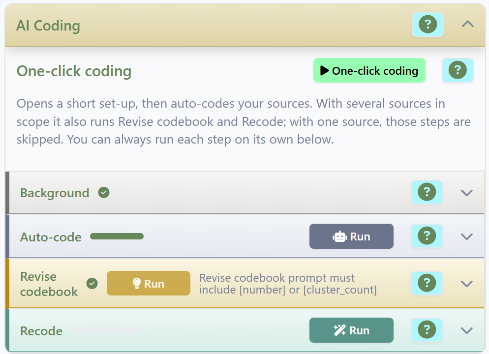

## Some recent projects

- **VIB, Brussels:** 100 HR interviews on career trajectories
- **Gender gap in STEM, Chile:** 32 student interviews
- **UK postdoc feedback:** mid-career drivers and obstacles to learning
- **British Academy:** Free-ranging interviews with former workshop participants
- **INTRAC:** one causal map across a 13-country governance programme
- **[Love Alliance](https://garden.causalmap.app/love-alliance):** end-term evaluation across ten African countries

# The workflow, three steps

The workflow, three steps

## Step 1: Start from the question

Before you touch the data, write down what you want to be able to say at the end, and to whom.

Every later choice follows from that one sentence: the data you gather, the labels you use, the maps you make.

## Be realistic about what it can answer

**Good at** yes

- which factors matter most
- what drives or follows from a factor
- how groups differ
- whether the evidence fits your theory of change

**Not for** no

- effect sizes
- proving X causes Y on its own

Pick questions the method can serve.

## Step 2: Code the claims

You write a short instruction for the AI, like a chatbot prompt, and it codes the links for you.

The golden rule: test on a small, varied sample, see exactly where the output is wrong or thin, fix the instruction, then scale up.

And one rule you never break: **every link needs a quote.** Without it you cannot show your working.

## Step 3: Check the links

However careful the coding, some links will be wrong.

If there are systematic errors, iterate the prompt until you are satisfied, then code the whole dataset.

Check them again before you analyse.

- tag the doubtful or surprising ones, to filter later
- note how sure each source sounds
- note how reliable each source is

# Using the Causal Map app

Using the Causal Map app

## It’s free!

- … All core functionality is free; unlimited projects of unlimited size, for as long as you want…
- … If you don’t mind other people viewing your maps.
- All users get free AI credits every month.
- You can switch off AI if you want.
- You can choose a region for AI processing if you want.
- You can get a subscription if you want private projects or extra features.

# Your map is a theory of change you can question

Your map is a theory of change you can question

## A filter is a question

Your links are not a static report. They are a living map you can question, over and over.

You ask a question by filtering. Women only. Everything downstream of training. Stack the filters and you answer a bigger question. The same data gives very different maps, each one just the result of a different question.

## Two everyday examples

**“What did the cash transfer lead to?”** Filter to that factor, look downstream. Out comes a map of every reported consequence, with counts.

**“Do women and men tell different stories?”** Split the same map by group. The links each group stresses light up differently.

## The transitivity trap

A pig farmer says the cash grant gave them more cash.

A wheat farmer says more cash let them buy more seed.

So cash grants lead to more seed?

No.

Two people, two stories, stitched into one that nobody told.

**The safe move:** keep only the sources whose own account runs all the way through.

## Step back and judge

Behind one tidy map there may still be hundreds of quotes. Does the claim hold up? Do the links really belong to the same context?

The AI can draft a source-by-source commentary on each pathway, doing only what a patient reader could. Treat it as a first draft and edit it.

## Let’s build a map, live

[figure not shown]

# A real evaluation: the Love Alliance

A real evaluation: the Love Alliance

## Too much data!

An end-term evaluation across ten African countries, with Southern Hemisphere.

We coded the narrative data for them.

176

documents: 79 country reports, 97 interview transcripts

22,000

causal claims, coded by AI

13,756

kept for the maps

No team could hand-code that and stay fresh. Every link still carries the quote it came from.

## Put a doubt to the data

Partway through, a fair worry surfaced: was the programme’s advocacy provoking a backlash against key populations?

Rather than trade impressions, we put the question to the data and traced it through the 43 sources that raised it. Every account pointed the other way: the support helped communities resist backlash, none named it as the cause.

> “also helping to counter the backlash against women’s rights and LGBT rights”

[Read the full Love Alliance case study](https://garden.causalmap.app/love-alliance)

# So what

So what

## The whole thing in one line

Code **“X influenced Y, with a quote”**. Capture everything, capture cheaply, let AI do it. Then judge, in the open.

This is not statistical proof. It is a disciplined way to assemble evidence, weigh it transparently, and reach a conclusion you can stand behind.

## Need the data first?

[figure not shown]

No interviews yet? QualiaInterviews can gather them. It runs a chat interview that asks people what changed and why, follows up in their own words, in any language.

The answers come back as narrative text, ready to code into a map.

## Come and try it

This is how we work at Causal Map Ltd, every day.

If you want to go from a stack of interviews to a theory of change you can defend, come and try it with us at **app.causalmap.app**.

## Resources

hello@causalmap.app

**App, free for public projects**  
app.causalmap.app

**Knowledge garden**  
garden.causalmap.app

Powell and Cabral (2025) AI-assisted causal mapping: a validation study. *IJSRM.*

Powell, Cabral and Mishan (2025) A workflow for collecting and understanding stories at scale. *Evaluation.*

Powell, Copestake and Remnant (2024) Causal mapping for evaluators. *Evaluation.*

Home